# yap1 dotplot panels (meox1 across levels, L3 DEG ratio, cell-cycle/p53 panel)

Kobayashi et al. 2036

Tyrone Chen

August 05, 2026

# 1 README

Three small standalone dotplot panels on the yap1 dataset:

1. `meox1` expression across all three annotation levels (L01/L02/L03) of the yap1 dataset - please review, note labels and cluster counts differ from previous dotplots the manuscript may already show, and let us know if anything needs to change on this end.
2. Ratio dotplot of `meox1` percent-expressed / log2FC in the merged LEC vs VEC DEG comparison (depends on `yap1_deg_confects_prep.Rmd` having been run first).
3. Cell-cycle/p53 gene panel dotplot by `L3_celltype` x `Genotype`.

## 1.1 Outputs

All under `../docs/figure_extended/dotplots/`:

- `yap1_dotplot_L01.pdf`, `yap1_dotplot_L02.pdf`, `yap1_dotplot_L03.pdf`
- `yap1_Level_03_DEG_mutVSwt_L3_celltype_merged_VEC_merged_LEC_fc0.00_minpct_0.01_meox1_ratio_dotplot.pdf`
- `yap1_dataset_Level_03_L3_celltype_genotype_cellcyclelec_cdkn1a_tp53_cdkn1bb.pdf`

## 1.2 meox1 across all annotation levels

Source: `yap1_dotplot_all_levels.R`.

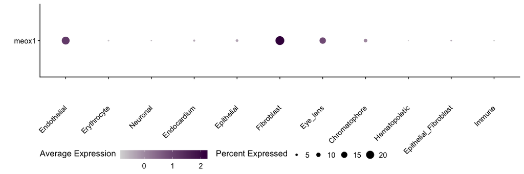

```r
library(ggplot2)
library(Seurat)
library(qs2)
outfile_dir <- "../docs/figure_extended/dotplots/"

features <- c("meox1")
rotate_x <- theme(axis.text.x = element_text(angle = 45, vjust = 0.5, hjust=1))
expression_colours <- c("#d9d9d9", "#40004b")

make_level_dotplot <- function(infile_path, outfile_name, ident_col) {
    level_data <- qs_read(infile_path)
    Idents(level_data) <- level_data@meta.data[[ident_col]]

    dotplot <- DotPlot(
        object = level_data,
        features = features,
        cluster.idents = F,
        cols = expression_colours
        ) + coord_flip() + rotate_x + ylab("") + xlab("") +
        guides(
            size = guide_legend(
                title = "Percent Expressed",
                direction = "horizontal"
            ),
            colour = guide_colorbar(
                title = "Average Expression",
                direction = "horizontal",
                barwidth = 10,
                barheight = 1
            )
        ) +
        theme(
            legend.position = "bottom",
            legend.box = "horizontal",
            legend.title = element_text(vjust = 1)
        )

    print(dotplot)

    ggsave(
        paste0(outfile_dir, outfile_name),
        dotplot,
        device="pdf",
        width=12,
        height=4
    )
}

#### L01 ####
make_level_dotplot(
    "../../Saki_data/paper/D10025_yap1_dataset_Level_01_annotated.qs2",
    "yap1_dotplot_L01.pdf",
    "L1_celltype"
)
```

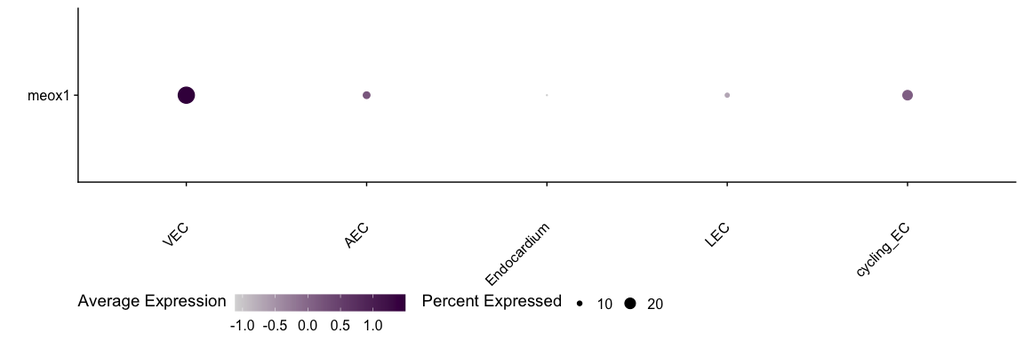

```r
#### L02 ####
make_level_dotplot(
    "../../Saki_data/paper/D10025_yap1_dataset_Level_02_annotated.qs2",
    "yap1_dotplot_L02.pdf",
    "L2_celltype"
)
```

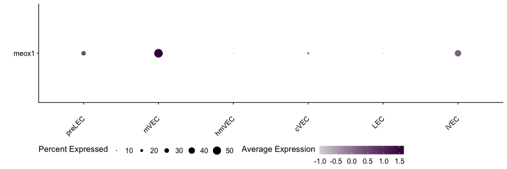

```r
#### L03 ####
make_level_dotplot(
    "../../Saki_data/paper/D10025_yap1_dataset_Level_03_annotated.qs2",
    "yap1_dotplot_L03.pdf",
    "L3_celltype"
)
```

## 1.3 L3 DEG ratio dotplot for meox1

Source: `yap1_dotplot_L3_degs.R`. Depends on `yap1_deg_confects_prep.Rmd` having generated the merged LEC/VEC DEG table first.

```r
library(ggpubr)
library(patchwork)
library(tidyverse)
```

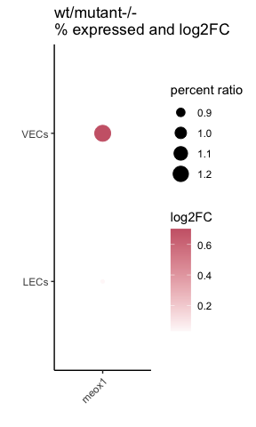

```r
make_ratio_dotplots <- function(deg_input,
                                width,
                                height,
                                path,
                                name){
    dotplot <- deg_input %>%
    mutate(.,`percent ratio` = pct.2/pct.1,
           `log2FC` = -avg_log2FC) %>%
    ggplot(.) +
    geom_point(aes(x= group, y = Gene, colour = log2FC, size = `percent ratio`)) +
    scale_colour_gradient2(low ='#332288',
                         high ='#CC6677',
                         na.value = "black",
                         guide = "colourbar",
                         midpoint = 0,
                         aesthetics = "colour") +
    theme(axis.text.x = element_text(angle = 45, vjust = 1, hjust=1)) +
    theme(panel.grid.major = element_blank(),
          panel.grid.minor = element_blank(),
          panel.background = element_blank(),
          axis.line = element_line(colour = "black"))  + xlab('') + ylab('') +
    ggtitle('wt/mutant-/-\n% expressed and log2FC') + coord_flip()

    filename <- sprintf('%s/%s_ratio_dotplot.pdf', path, name)
    ggsave(filename,
            dotplot,
            device="pdf",
            width=width,
            height=height)
    return(dotplot)
}

infile_path <- "../docs/figure_extended/dge_confects/yap1_Level_03_DEG_mutVSwt_L3_celltype_merged_VEC_merged_LEC_fc0.00_minpct_0.01.csv"
outfile_name <- "yap1_Level_03_DEG_mutVSwt_L3_celltype_merged_VEC_merged_LEC_fc0.00_minpct_0.01_meox1"
gene_degs <- read_csv(infile_path)
input_ratio <- gene_degs %>%
    filter(Gene == "meox1") %>%
    mutate(group = recode(
        group, "LEC__preLEC" = "LECs", "cVEC__hmVEC__mVEC" = "VECs")
        ) %>%
    mutate(group=factor(group, levels=c("LECs", "VECs")))

plt <- make_ratio_dotplots(input_ratio, width = 3, height = 5,
                    name = outfile_name, path = outfile_dir)
print(plt)
```

## 1.4 Cell-cycle / p53 panel

Source: `yap1_add_genes_to_dotplot.R`. Same panel and rationale as `meox1_dotplot_panels.Rmd`’s cell-cycle section, applied to the yap1 dataset (note the extra `cVEC`/`iVEC` levels vs meox1’s L3 celltype set).

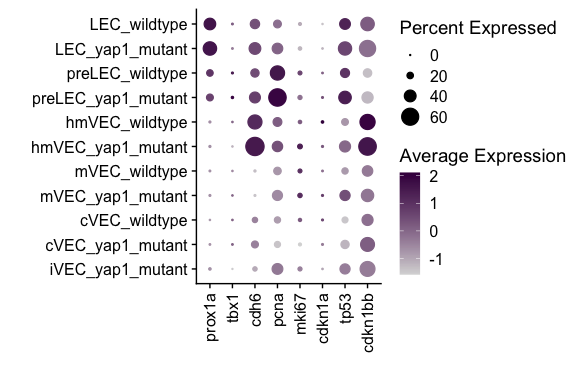

```r
features_cellcycle <- c(
    "prox1a", "tbx1", "cdh6", "pcna", "mki67", "cdkn1a", "tp53", "cdkn1bb"
    )
rotate_x_90 <- theme(axis.text.x = element_text(angle = 90, vjust = 0.5, hjust=1))

genotype_colours <- c(
  "#dbe2c6", #wildtype
  "#657c95" #mutant
)
expression_colours <- c("#d9d9d9", "#40004b")
cols_cellcycle <- c( '#ffff66', '#cc85ff','#a0d0e0')
names(cols_cellcycle) <- c("G1/G0", "S", "G2M")

level_03_celltype_genotype_order <- c(
    "LEC_wildtype",
    "LEC_yap1_mutant",
    "preLEC_wildtype",
    "preLEC_yap1_mutant",
    "hmVEC_wildtype",
    "hmVEC_yap1_mutant",
    "mVEC_wildtype",
    "mVEC_yap1_mutant",
    "cVEC_wildtype",
    "cVEC_yap1_mutant",
    "iVEC_wildtype",
    "iVEC_yap1_mutant"
)

level_03 <- qs_read("../../Saki_data/paper/D10025_yap1_dataset_Level_03_annotated.qs2")

level_03_relevel <- level_03
level_03_relevel$L3_celltype_genotype <- paste0(
    level_03_relevel$L3_celltype, "_", level_03_relevel$Genotype
    )
level_03_relevel <- SetIdent(
    level_03_relevel, value="L3_celltype_genotype"
    )
Idents(level_03_relevel) <- factor(
    level_03_relevel@active.ident, rev(
        level_03_celltype_genotype_order
        )
    )

dotplot_cellcycle <- DotPlot(
    object = level_03_relevel,
    features = features_cellcycle,
    cluster.idents = F,
    cols = expression_colours
    ) + rotate_x_90 + ylab("") + xlab("")

print(dotplot_cellcycle)
```

```r
ggsave(
    paste0(outfile_dir, "yap1_dataset_Level_03_L3_celltype_genotype_cellcyclelec_cdkn1a_tp53_cdkn1bb.pdf"),
    dotplot_cellcycle,
    device="pdf",
    width=6,
    height=4
)
```

## 1.5 For developers

Sample run command:

```bash
Rscript -e "
rmarkdown::render(
  'yap1_dotplot_panels.Rmd',
  output_file = './yap1_dotplot_panels.html'
)
"
```